# 1. Import Libraries, Load Dataset, print shape, Data description

```python
import pandas as pd             # Import Pandas
import warnings
import numpy as np              # Import numpy
import re,string,unicodedata    # Import Regex, string and unicodedata.
import nltk                     # Import Natural Language Tool-Kit
import seaborn as sns           # Import seaborn
import matplotlib.pyplot as plt
%matplotlib inline

from sklearn.model_selection import train_test_split
from mlxtend.plotting import plot_confusion_matrix
from sklearn.tree import DecisionTreeClassifier
from sklearn.ensemble import RandomForestClassifier
from sklearn.metrics import accuracy_score,confusion_matrix,classification_report
from nltk import sent_tokenize,  word_tokenize # sentence & word tokenization library
from nltk.stem.snowball import SnowballStemmer # Import Stemmatizer
from nltk.stem.wordnet import WordNetLemmatizer #Import Lemmatizer
from nltk.corpus import stopwords,wordnet #Import Tokenizer
from nltk.stem import PorterStemmer
from bs4 import BeautifulSoup           #IMport BeautifulSoup
from nltk.stem import LancasterStemmer, WordNetLemmatizer
from wordcloud import WordCloud,STOPWORDS
import itertools
import collections
```

```python
nltk.download('punkt')
nltk.download('wordnet')
nltk.download('stopwords')  #Download Stopwards
```

```
True
```

```python
!pip install contractions
```

```
     |████████████████████████████████| 317kB 4.3MB/s
     |████████████████████████████████| 245kB 27.9MB/s
```

```python
import contractions # Import contractions library.
```

```python
from google.colab import drive
drive.mount('/content/drive')
```

```python
tweet_df = pd.read_csv("/content/drive/My Drive/Colab Notebooks/Tweets.csv", encoding= 'utf-8')
```

```python
tweet_df.head(3)
```

|  | tweet_id | airline_sentiment | airline_sentiment_confidence | negativereason | negativereason_confidence | airline | airline_sentiment_gold | name | negativereason_gold | retweet_count | text | tweet_coord | tweet_created | tweet_location | user_timezone |
| --- | --- | --- | --- | --- | --- | --- | --- | --- | --- | --- | --- | --- | --- | --- | --- |
| 0 | 570306133677760513 | neutral | 1.0000 | NaN | NaN | Virgin America | NaN | cairdin | NaN | 0 | @VirginAmerica What @dhepburn said. | NaN | 2015-02-24 11:35:52 -0800 | NaN | Eastern Time (US & Canada) |
| 1 | 570301130888122368 | positive | 0.3486 | NaN | 0.0 | Virgin America | NaN | jnardino | NaN | 0 | @VirginAmerica plus you've added commercials t... | NaN | 2015-02-24 11:15:59 -0800 | NaN | Pacific Time (US & Canada) |
| 2 | 570301083672813571 | neutral | 0.6837 | NaN | NaN | Virgin America | NaN | yvonnalynn | NaN | 0 | @VirginAmerica I didn't today... Must mean I n... | NaN | 2015-02-24 11:15:48 -0800 | Lets Play | Central Time (US & Canada) |

```python
tweet_df.tail(3)
```

|  | tweet_id | airline_sentiment | airline_sentiment_confidence | negativereason | negativereason_confidence | airline | airline_sentiment_gold | name | negativereason_gold | retweet_count | text | tweet_coord | tweet_created | tweet_location | user_timezone |
| --- | --- | --- | --- | --- | --- | --- | --- | --- | --- | --- | --- | --- | --- | --- | --- |
| 14637 | 569587242672398336 | neutral | 1.0000 | NaN | NaN | American | NaN | sanyabun | NaN | 0 | @AmericanAir Please bring American Airlines to... | NaN | 2015-02-22 11:59:15 -0800 | Nigeria,lagos | NaN |
| 14638 | 569587188687634433 | negative | 1.0000 | Customer Service Issue | 0.6659 | American | NaN | SraJackson | NaN | 0 | @AmericanAir you have my money, you change my ... | NaN | 2015-02-22 11:59:02 -0800 | New Jersey | Eastern Time (US & Canada) |
| 14639 | 569587140490866689 | neutral | 0.6771 | NaN | 0.0000 | American | NaN | daviddtwu | NaN | 0 | @AmericanAir we have 8 ppl so we need 2 know h... | NaN | 2015-02-22 11:58:51 -0800 | dallas, TX | NaN |

```python
print(tweet_df.shape) # print shape of data
```

```
(14640, 15)
```

- No of Row in the Dataset: 14,640
- No of column in the Dataset: 15

```python
tweet_df.columns
```

```
Index(['tweet_id', 'airline_sentiment', 'airline_sentiment_confidence',
       'negativereason', 'negativereason_confidence', 'airline',
       'airline_sentiment_gold', 'name', 'negativereason_gold',
       'retweet_count', 'text', 'tweet_coord', 'tweet_created',
       'tweet_location', 'user_timezone'],
      dtype='object')
```

```python
tweet_df.describe().T
```

|  | count | mean | std | min | 25% | 50% | 75% | max |
| --- | --- | --- | --- | --- | --- | --- | --- | --- |
| tweet_id | 14640.0 | 5.692184e+17 | 7.791112e+14 | 5.675883e+17 | 5.685592e+17 | 5.694779e+17 | 5.698905e+17 | 5.703106e+17 |
| airline_sentiment_confidence | 14640.0 | 9.001689e-01 | 1.628300e-01 | 3.350000e-01 | 6.923000e-01 | 1.000000e+00 | 1.000000e+00 | 1.000000e+00 |
| negativereason_confidence | 10522.0 | 6.382983e-01 | 3.304398e-01 | 0.000000e+00 | 3.606000e-01 | 6.706000e-01 | 1.000000e+00 | 1.000000e+00 |
| retweet_count | 14640.0 | 8.265027e-02 | 7.457782e-01 | 0.000000e+00 | 0.000000e+00 | 0.000000e+00 | 0.000000e+00 | 4.400000e+01 |

```python
tweet_df.dtypes # data type
```

```
tweet_id                          int64
airline_sentiment                object
airline_sentiment_confidence    float64
negativereason                   object
negativereason_confidence       float64
airline                          object
airline_sentiment_gold           object
name                             object
negativereason_gold              object
retweet_count                     int64
text                             object
tweet_coord                      object
tweet_created                    object
tweet_location                   object
user_timezone                    object
dtype: object
```

```python
tweet_df.info()
```

```
<class 'pandas.core.frame.DataFrame'>
RangeIndex: 14640 entries, 0 to 14639
Data columns (total 15 columns):
 #   Column                        Non-Null Count  Dtype
---  ------                        --------------  -----
 0   tweet_id                      14640 non-null  int64
 1   airline_sentiment             14640 non-null  object
 2   airline_sentiment_confidence  14640 non-null  float64
 3   negativereason                9178 non-null   object
 4   negativereason_confidence     10522 non-null  float64
 5   airline                       14640 non-null  object
 6   airline_sentiment_gold        40 non-null     object
 7   name                          14640 non-null  object
 8   negativereason_gold           32 non-null     object
 9   retweet_count                 14640 non-null  int64
 10  text                          14640 non-null  object
 11  tweet_coord                   1019 non-null   object
 12  tweet_created                 14640 non-null  object
 13  tweet_location                9907 non-null   object
 14  user_timezone                 9820 non-null   object
dtypes: float64(2), int64(2), object(11)
memory usage: 1.7+ MB
```

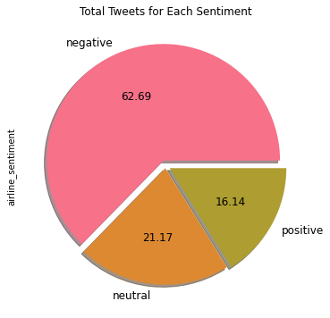

```python
colors=sns.color_palette("husl", 10)
pd.Series(tweet_df["airline_sentiment"]).value_counts().plot(kind="pie",colors=colors,
    labels=["negative", "neutral", "positive"],explode=[0.05,0.02,0.04],
    shadow=True,autopct='%.2f', fontsize=12,figsize=(6, 6),title = "Total Tweets for Each Sentiment")
```

- Negative Sentiment : 62.69%
- Positive Sentiment : 16.14%
- Neutral Sentiment : 21.17%

# 2. Understand the data-Columns:

- Drop all other colums except "text" and "airline_sentiment"
- Check the shape of data
- Print first 5 rows of data

```python
# Drop all other columns except "text" and "airline_sentiment"

tweet_df = tweet_df[['text', 'airline_sentiment']]
```

```python
#Check the shape of data
tweet_df.shape
```

```
(14640, 2)
```

New shape on the remove of unneeded columns are

- No of row: 14,640
- No of Column: 2

```python
#Print first 5 rows of data
tweet_df.head(5)
```

|  | text | airline_sentiment |
| --- | --- | --- |
| 0 | @VirginAmerica What @dhepburn said. | neutral |
| 1 | @VirginAmerica plus you've added commercials t... | positive |
| 2 | @VirginAmerica I didn't today... Must mean I n... | neutral |
| 3 | @VirginAmerica it's really aggressive to blast... | negative |
| 4 | @VirginAmerica and it's a really big bad thing... | negative |

# Further analysis of given data: EDA

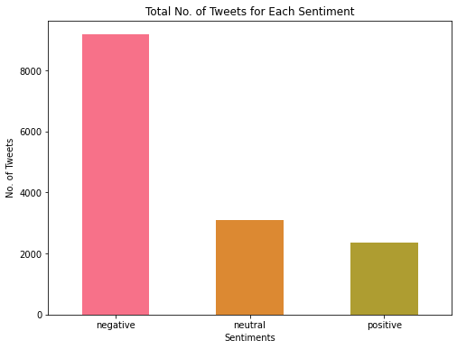

```python
#Plotting the number of each type of sentiments
colors=sns.color_palette("husl", 10)
pd.Series(tweet_df["airline_sentiment"]).value_counts().plot(kind = "bar",
                                    color=colors,figsize=(8,6),rot=0, title = "Total No. of Tweets for Each Sentiment")
plt.xlabel('Sentiments', fontsize=10)
plt.ylabel('No. of Tweets', fontsize=10)
```

```python
# Class Distribution or prediction variable
tweet_df['airline_sentiment'].value_counts()/len(tweet_df)
```

```
negative    0.626913
neutral     0.211680
positive    0.161407
Name: airline_sentiment, dtype: float64
```

```python
print("Nos of tweet with Positive sentiment = ",len(tweet_df[tweet_df['airline_sentiment'] == 'positive']))
print("Nos of tweet with Negative sentiment = ",len(tweet_df[tweet_df['airline_sentiment'] == 'negative']))
print("Nos of tweet with Neutral sentiment = ",len(tweet_df[tweet_df['airline_sentiment'] == 'neutral']))
```

```
Nos of tweet with Positive sentiment =  2363
Nos of tweet with Negative sentiment =  9178
Nos of tweet with Neutral sentiment =  3099
```

```python
tweet_df.info()
```

```
<class 'pandas.core.frame.DataFrame'>
RangeIndex: 14640 entries, 0 to 14639
Data columns (total 2 columns):
 #   Column             Non-Null Count  Dtype
---  ------             --------------  -----
 0   text               14640 non-null  object
 1   airline_sentiment  14640 non-null  object
dtypes: object(2)
memory usage: 228.9+ KB
```

```python
tweet_df.isnull().sum(axis=0)
```

```
text                 0
airline_sentiment    0
dtype: int64
```

There are no null values in the dataset

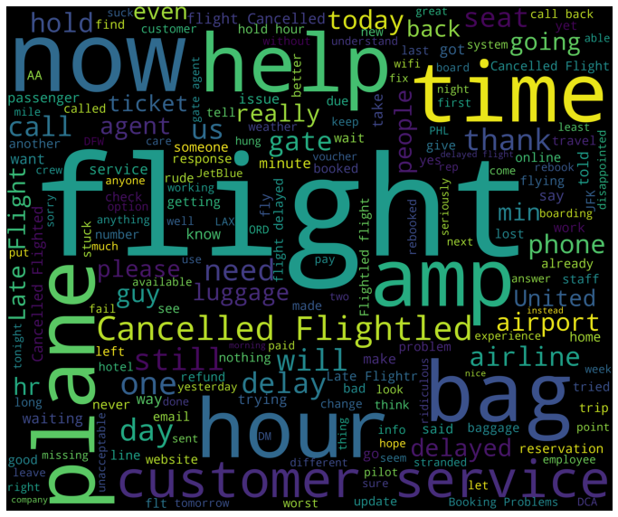

```python
df_negative = tweet_df[tweet_df['airline_sentiment']=='negative']
words = ' '.join(df_negative['text'])
cleaned_word = " ".join([word for word in words.split()
                            if 'http' not in word
                                and not word.startswith('@')
                                and word != 'RT'
                            ])
wordcloud = WordCloud(stopwords=STOPWORDS,
                      background_color='black',
                      width=3000,
                      height=2500
                     ).generate(cleaned_word)


plt.figure(1,figsize=(12, 12))
plt.imshow(wordcloud)
plt.axis('off')
plt.show()
```

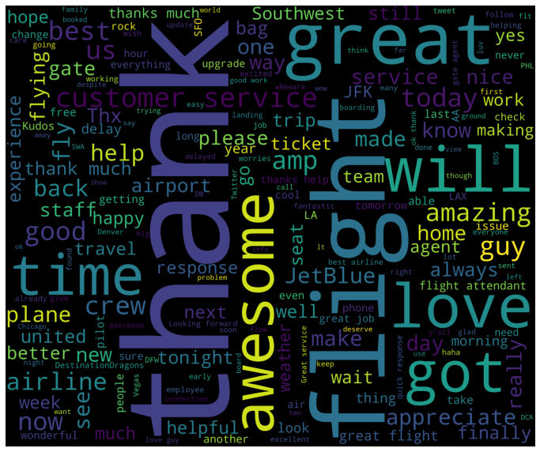

```python
#visualization using wordcloud for the positive tweets
df_postive = tweet_df [tweet_df['airline_sentiment']=='positive']
words = ' '.join(df_postive['text'])
cleaned_word = " ".join([word for word in words.split()
                            if 'http' not in word
                                and not word.startswith('@')
                                and word != 'RT'])
wordcloud = WordCloud(stopwords=STOPWORDS,
                      background_color='black',
                      width=3000,
                      height=2500
                     ).generate(cleaned_word)


plt.figure(1,figsize=(12, 12))
plt.imshow(wordcloud)
plt.axis('off')
plt.show()
```

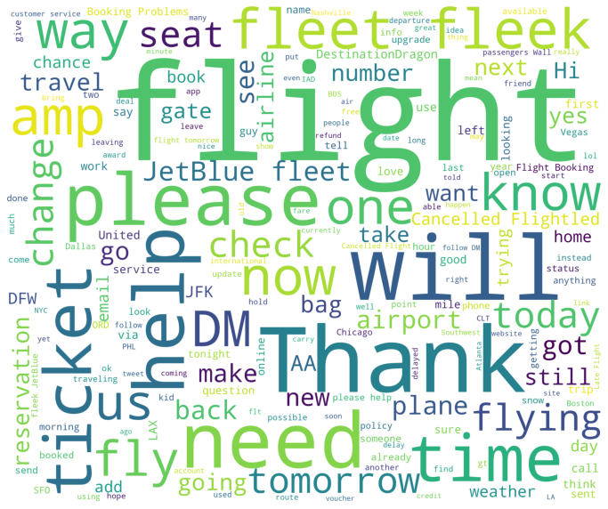

```python
#visualization using wordcloud for the neutral tweets
df_neutral = tweet_df[tweet_df['airline_sentiment']=='neutral']
words = ' '.join(df_neutral['text'])
cleaned_word = " ".join([word for word in words.split()
                            if 'http' not in word
                                and not word.startswith('@')
                                and word != 'RT'])
wordcloud = WordCloud(stopwords=STOPWORDS,
                      background_color='white',
                      width=3000,
                      height=2500
                     ).generate(cleaned_word)

plt.figure(1,figsize=(12, 12))
plt.imshow(wordcloud)
plt.axis('off')
plt.show()
```

Wordcloud used to give a pictorial representation of words that makes up each of the sentiment, Negative, Neutral and Positive.

The bigger characters are the most used characters.

# 3. Text Pre-processing: Data Preparation

- Html tag removal
- Tokenization
- Remove the number
- Removal of Special Characters and Punctuations
- Conversion to lowercase
- Lemmatize or stemming
- Join the words in the list to convert back to text string in the dataframe ( So that each row contains the data in text format)
- Print first 5 rows of data after pre-processing

# Noise reduction via Data Clean up

We have used NLTK library to tokenize words , remove stopwords and lemmatize the remaining words

```python
def strip_html(text):
    soup = BeautifulSoup(text, "html.parser")
    return soup.get_text()

tweet_df['text'] = tweet_df['text'].apply(lambda x: strip_html(x))
tweet_df.head()
```

|  | text | airline_sentiment |
| --- | --- | --- |
| 0 | @VirginAmerica What @dhepburn said. | neutral |
| 1 | @VirginAmerica plus you've added commercials t... | positive |
| 2 | @VirginAmerica I didn't today... Must mean I n... | neutral |
| 3 | @VirginAmerica it's really aggressive to blast... | negative |
| 4 | @VirginAmerica and it's a really big bad thing... | negative |

BeautifulSoup used for scrapping html markup from the text

```python
def replace_contractions(text):
    """Replace contractions in string of text"""
    return contractions.fix(text)

tweet_df['text'] = tweet_df['text'].apply(lambda x: replace_contractions(x))
tweet_df.head()
```

|  | text | airline_sentiment |
| --- | --- | --- |
| 0 | @VirginAmerica What @dhepburn said. | neutral |
| 1 | @VirginAmerica plus you have added commercials... | positive |
| 2 | @VirginAmerica I did not today... Must mean I ... | neutral |
| 3 | @VirginAmerica it is really aggressive to blas... | negative |
| 4 | @VirginAmerica and it is a really big bad thin... | negative |

```python
def remove_numbers(text):
  text = re.sub(r'\d+', '', text)
  return text

tweet_df['text'] = tweet_df['text'].apply(lambda x: remove_numbers(x))
tweet_df.head()
```

|  | text | airline_sentiment |
| --- | --- | --- |
| 0 | @VirginAmerica What @dhepburn said. | neutral |
| 1 | @VirginAmerica plus you have added commercials... | positive |
| 2 | @VirginAmerica I did not today... Must mean I ... | neutral |
| 3 | @VirginAmerica it is really aggressive to blas... | negative |
| 4 | @VirginAmerica and it is a really big bad thin... | negative |

```python
tweet_df['text'] = tweet_df.apply(lambda row: nltk.word_tokenize(row['text']), axis=1) # Tokenization of data
```

```python
tweet_df.head()                                                                    # Look at how tokenized data looks.
```

|  | text | airline_sentiment |
| --- | --- | --- |
| 0 | [@, VirginAmerica, What, @, dhepburn, said, .] | neutral |
| 1 | [@, VirginAmerica, plus, you, have, added, com... | positive |
| 2 | [@, VirginAmerica, I, did, not, today, ..., Mu... | neutral |
| 3 | [@, VirginAmerica, it, is, really, aggressive,... | negative |
| 4 | [@, VirginAmerica, and, it, is, a, really, big... | negative |

```python
stopwords = stopwords.words('english')

customlist = ['not', "couldn't", 'didn', "didn't", 'doesn', "doesn't", 'hadn', "hadn't", 'hasn',
        "hasn't", 'haven', "haven't", 'isn', "isn't", 'ma', 'mightn', "mightn't", 'mustn',
        "mustn't", 'needn', "needn't", 'shan', "shan't", 'shouldn', "shouldn't", 'wasn',
        "wasn't", 'weren', "weren't", 'won', "won't", 'wouldn', "wouldn't"]

# Set custom stop-word's list as not, couldn't etc. words matter in Sentiment, so not removing them from original data.

stopwords = list(set(stopwords) - set(customlist))
```

```python
lemmatizer = WordNetLemmatizer()

def remove_non_ascii(words):
    """Remove non-ASCII characters from list of tokenized words"""
    new_words = []
    for word in words:
        new_word = unicodedata.normalize('NFKD', word).encode('ascii', 'ignore').decode('utf-8', 'ignore')
        new_words.append(new_word)
    return new_words

def to_lowercase(words):
    """Convert all characters to lowercase from list of tokenized words"""
    new_words = []
    for word in words:
        new_word = word.lower()
        new_words.append(new_word)
    return new_words

def remove_punctuation(words):
    """Remove punctuation from list of tokenized words"""
    new_words = []
    for word in words:
        new_word = re.sub(r'[^\w\s]', '', word)
        if new_word != '':
            new_words.append(new_word)
    return new_words

def remove_stopwords(words):
    """Remove stop words from list of tokenized words"""
    new_words = []
    for word in words:
        if word not in stopwords:
            new_words.append(word)
    return new_words

def lemmatize_list(words):
    new_words = []
    for word in words:
      new_words.append(lemmatizer.lemmatize(word, pos='v'))
    return new_words

def normalize(words):
    words = remove_non_ascii(words)
    words = to_lowercase(words)
    words = remove_punctuation(words)
    words = remove_stopwords(words)
    words = lemmatize_list(words)
    return ' '.join(words)

tweet_df['text'] = tweet_df.apply(lambda row: normalize(row['text']), axis=1)
tweet_df.head()
```

|  | text | airline_sentiment |
| --- | --- | --- |
| 0 | virginamerica dhepburn say | neutral |
| 1 | virginamerica plus add commercials experience ... | positive |
| 2 | virginamerica not today must mean need take an... | neutral |
| 3 | virginamerica really aggressive blast obnoxiou... | negative |
| 4 | virginamerica really big bad thing | negative |

further Data clean up and splitting

```python
tweet_df.columns
```

```
Index(['text', 'airline_sentiment'], dtype='object')
```

```python
tweet_df["airline_sentiment"]
```

```
0         neutral
1        positive
2         neutral
3        negative
4        negative
           ...
14635    positive
14636    negative
14637     neutral
14638    negative
14639     neutral
Name: airline_sentiment, Length: 14640, dtype: object
```

```python
df=tweet_df   # making backup copy of the dataset
```

```python
df.loc[:,'airline_sentiment'] = df.airline_sentiment.map({'negative':0,'neutral':2,'positive':1}) #assinging numeric to the object data type
```

```python
df.head()
```

|  | text | airline_sentiment |
| --- | --- | --- |
| 0 | virginamerica dhepburn say | 2 |
| 1 | virginamerica plus add commercials experience ... | 1 |
| 2 | virginamerica not today must mean need take an... | 2 |
| 3 | virginamerica really aggressive blast obnoxiou... | 0 |
| 4 | virginamerica really big bad thing | 0 |

```python
labels =df["airline_sentiment"]
```

```python
labels = labels.astype('int') #convert data type to integer
```

# The data is split in the standard 80,20 ratio.

```python
train,test = train_test_split(df,test_size=0.2,random_state=42)
```

```python
train_clean_tweet=[]
for tweet in train['text']:
    train_clean_tweet.append(tweet)
test_clean_tweet=[]
for tweet in test['text']:
    test_clean_tweet.append(tweet)
```

4.Vectorization:

- Use CountVectorizer.
- Use TfidfVectorizer

# Running the algorthim using CountVectorizer

```python
# Vectorization (Convert text data to numbers).
from sklearn.feature_extraction.text import CountVectorizer

vectorizer = CountVectorizer(max_features=1000)                # Keep only 1000 features as number of features will increase the processing time.
data_features = vectorizer.fit_transform(tweet_df['text'])

data_features = data_features.toarray()
```

```python
#Using TfidfVectorizer to convert text data to numbers.

from sklearn.feature_extraction.text import TfidfVectorizer

vectorizer = TfidfVectorizer(max_features=1000)
data_features = vectorizer.fit_transform(tweet_df['text'])

data_features2 = data_features.toarray()

data_features2.shape
```

```
(14640, 1000)
```

# 5. Fit and evaluate modelusing both type of vectorization

Prediciting sentiments from tweet text data

- Decision Tree Classifier
- Random Forest Classifier

```python
Classifiers = [
    DecisionTreeClassifier(),
    RandomForestClassifier(n_estimators=200)]
```

```
Accuracy of DecisionTreeClassifieris 0.7192622950819673
              precision    recall  f1-score   support

           0       0.82      0.82      0.82      1879
           1       0.64      0.60      0.62       490
           2       0.46      0.47      0.46       559

    accuracy                           0.72      2928
   macro avg       0.64      0.63      0.63      2928
weighted avg       0.72      0.72      0.72      2928
```

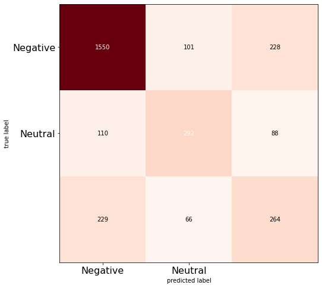

```
Accuracy of RandomForestClassifieris 0.7807377049180327
              precision    recall  f1-score   support

           0       0.92      0.83      0.87      2101
           1       0.62      0.75      0.68       379
           2       0.46      0.60      0.52       448

    accuracy                           0.78      2928
   macro avg       0.67      0.72      0.69      2928
weighted avg       0.81      0.78      0.79      2928
```

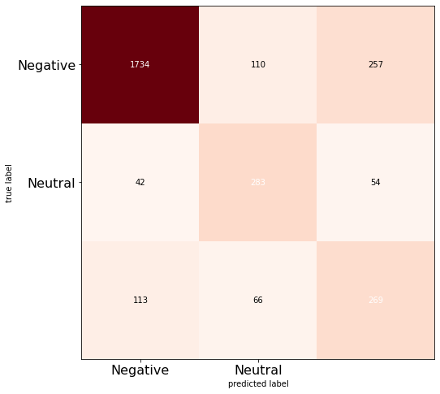

```python
# Using CountVectorizer
dense_features=train_features.toarray()
dense_test= test_features.toarray()
Accuracy=[]
Model=[]
for classifier in Classifiers:
    try:
        fit = classifier.fit(train_features,train['airline_sentiment'])
        pred = fit.predict(test_features)
    except Exception:
        fit = classifier.fit(dense_features,train['airline_sentiment'])
        pred = fit.predict(dense_test)
    accuracy = accuracy_score(pred,test['airline_sentiment'])
    Accuracy.append(accuracy)
    print()
    Model.append(classifier.__class__.__name__)
    print('Accuracy of '+classifier.__class__.__name__+'is '+str(accuracy))
    print(classification_report(pred,test['airline_sentiment']))
    cm=confusion_matrix(pred , test['airline_sentiment'])
    plt.figure()
    plot_confusion_matrix(cm,figsize=(12,8), hide_ticks=True,cmap=plt.cm.Reds)
    plt.xticks(range(2), ['Negative', 'Neutral', 'Positive'], fontsize=16,color='black')
    print()
    plt.yticks(range(2), ['Negative', 'Neutral', 'Positive'], fontsize=16)
    plt.show()
```

Observation

- Comparing 2 algorithm. Decision tree performed at 72%
- Random Forest algorithm performed at 78%
- This is based on countvectorizer.

# Using TFidVectorizer and comparing result with 2 algorithm, Decision Tree and Radom Forest

```python
#Using TfidfVectorizer to convert text data to numbers.

from sklearn.feature_extraction.text import TfidfVectorizer

vectorizer = TfidfVectorizer(max_features=1000)
data_features = vectorizer.fit_transform(tweet_df['text'])

data_features2 = data_features.toarray()

data_features2.shape
```

```
(14640, 1000)
```

```python
Classifiers = [
    DecisionTreeClassifier(),
    RandomForestClassifier(n_estimators=200)]
```

```
Accuracy of DecisionTreeClassifieris 0.6827185792349727
              precision    recall  f1-score   support

           0       0.79      0.79      0.79      1897
           1       0.55      0.58      0.56       437
           2       0.43      0.42      0.42       594

    accuracy                           0.68      2928
   macro avg       0.59      0.59      0.59      2928
weighted avg       0.68      0.68      0.68      2928

Accuracy of RandomForestClassifieris 0.7797131147540983
              precision    recall  f1-score   support

           0       0.95      0.80      0.87      2235
           1       0.55      0.80      0.65       314
           2       0.42      0.64      0.51       379

    accuracy                           0.78      2928
   macro avg       0.64      0.75      0.68      2928
weighted avg       0.84      0.78      0.80      2928
```

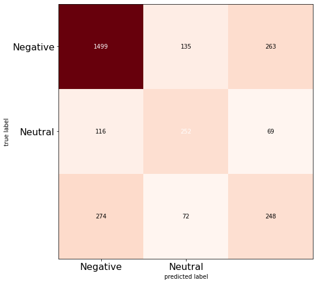

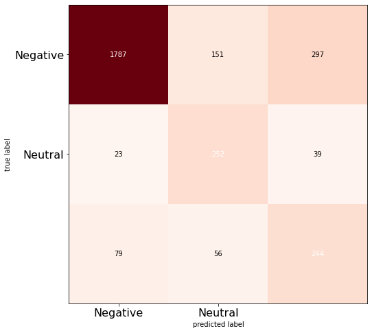

```python
dense_features=train_features2.toarray()
dense_test= test_features2.toarray()
Accuracy=[]
Model=[]
for classifier in Classifiers:
    try:
        fit = classifier.fit(train_features2,train['airline_sentiment'])
        pred = fit.predict(test_features2)
    except Exception:
        fit = classifier.fit(dense_features,train['airline_sentiment'])
        pred = fit.predict(dense_test)
    accuracy = accuracy_score(pred,test['airline_sentiment'])
    Accuracy.append(accuracy)
    Model.append(classifier.__class__.__name__)
    print('Accuracy of '+classifier.__class__.__name__+'is '+str(accuracy))
    print(classification_report(pred,test['airline_sentiment']))
    cm=confusion_matrix(pred , test['airline_sentiment'])
    plt.figure()
    plot_confusion_matrix(cm,figsize=(12,8), hide_ticks=True,cmap=plt.cm.Reds)
    plt.xticks(range(2), ['Negative', 'Neutral', 'Positive'], fontsize=16,color='black')
    plt.yticks(range(2), ['Negative', 'Neutral', 'Positive'], fontsize=16)
```

Observation:

- Decision Tree performed at 68% accuracy
- Random forest performed at 78% accuracy
- This based on TFIDVectorizer

# 6. Summarize your understanding of the application of Various Pre-processing and Vectorization and performance of your model on the dataset

- Our goal was to build a model for text-classification.
- We Pre-processed the data using variuos techniques and libraries. The pre-precessed data is converted to numbers, so that we can feed the data in the model.
- Various pre-processed method were used such as BeautifulSoup for removing HTML tags, We removed noise from the text by removing ASCII codes and special character, used contradiction to remove hyphens. Normalized the text by converting all text to lowercase. using lammentization instead of stemming because we intend to use the best dictionary vocabulary. finally rejoin the clean text back together.
- We convert the labels from object to integer for easy processing.
- After building the classification model, we predicted the result for the test data.
- After that we saw that using the above techniques, our model performed good in perspective of how the text classification models perform.
- As we you can see above we have plotted the confusion matrix for predicted sentiments and actual sentiments (negative,neutral and positive)
- Random Forest Classifier gives us the best accuracy score, precision scores according to the classification report.
- The confusion matrix shows the TP,TN,FP,FN for all the 3 sentiments(negative,neutral and positive),Here also Random Forest Classifier gives better results than the Decision Tree Classifier.